# Churn Prediction - Comparing Multiple Models

Georgios Karaliolios

2024-03-21

# Abstract

This project report delves into identifying critical factors and the most effective predictive model for customer churn at a Dutch energy provider, a pressing issue in the competitive European energy sector. By meticulously analyzing a dataset of 20,000 customer observations, the study executed a thorough data preparation process including outlier removal and the introduction of a new variable for better understanding customer behavior. The investigation compared various predictive models, including Logistic Regression, Decision Trees, Gradient Boosting, and others, concluding that Gradient Boosting outperformed the rest. Key findings underscore the significance of service usage, relationship length, contract length, and flexible contracts in influencing customer churn. Notably, longer relationships and contract durations correlated with lower churn rates. The report suggests that the energy supplier could enhance customer retention strategies by focusing on long-term relationships and stable contract terms, alongside developing energy efficiency programs for high-usage customers, thereby fostering loyalty and reducing churn.

## Managerial Summary

This project is dedicated to identifying the key factors and the most effective model for predicting customer churn for a Dutch energy provider. This task is especially critical in the European energy sector, where market liberalization has ramped up competition, making customer retention maybe the most important focus for companies in this sector.  
The examined dataset consists of 20,000 customer observations, carefully refined through a comprehensive data cleaning and preparation process. This involved the identification and removal of outliers, particularly in critical variables such as income, electricity, and gas usage, to enhance the integrity of the analysis. Additionally, a new variable is introduced to better understand customer behavior, the “flexible_contract”, on which contracts could be terminated at any time.  
The baseline model for this study comprises a logistic regression model and it is constructed based on the study’s hypotheses, deriving from the literature review and the exploratory analysis. As a result, it includes the variables gender, age, income, relation length, electricity usage, gas usage, contract length, and flexible contract. Subsequently, different methods are implemented to test their performance and to determine the most important attributes for the specific task. The methods under comparison are Logistic Regression, Stepwise Logistic Regression, Decision Tree model, Gradient Boosting, Random Forest, Support Vector Machine, and Neural Network. The model that emerged as the better performing based on various evaluation metrics is the gradient boosting model.  
Regarding the most important attributes, this study highlights several key variables significantly impacting customer churn. Service usage, relationship length, and contract length are the most influential determinants. Notably, customers with longer relationships and more extended contract terms exhibited lower churn rates.  
In conclusion, the energy supplier can tailor their customer retention strategies more effectively, focusing on long-term relationships, and stable contract terms, and develop energy efficiency programs for customers with higher energy usage.

## Data Description

The dataset, comprising 20,000 customer observations from a Dutch energy supplier, underwent an initial summary check to identify any potential anomalies. The examination revealed the absence of any missing values within the dataset. The variables are converted to different types, in order to give them the appropriate format. A descriptive statistics table for numerical and categorical variables is then created (Table 1). Based on this table, important insights are gained. It is noticed that most of the customers are older and have moderate income. Most of the customers are loyal as the mean relationship length is almost 5 years.  
*For a detailed description of the different factors, refer to Appendix 1

#### Data Descriptives

[figure not shown]

### Data Cleaning & EDA

The first step in the EDA and data cleaning process involves checking for missing values, while the second step focuses on converting factors into their appropriate forms

```r
# Data Cleaning & Descriptives ----
# Reviewing missing values
for(col in names(data)) {
  missing_values <- sum(is.na(data[[col]]))
  print(paste("Column", col, "has", missing_values, "missing values."))}
# no missings
# Removing Customer_ID
data$Customer_ID <- NULL
# Convert the variables into the appropriate form
# columns to convert
factor_var <- c('Churn', 'Gender', 'Email_list', 'Home_label', 'Start_channel', 'Province')
numeric_var <- c('Electricity_usage', 'Gas_usage', 'Income')
integer_var <- c('Age', 'Home_age', 'Relation_length', 'Contract_length')
# Converting factor variables
for(var in factor_var){
  data[[var]] <- as.factor(data[[var]])}
# Converting numeric variables
for(var in numeric_var){
  data[[var]] <- as.numeric(data[[var]])}
# Converting integer variables
for(var in integer_var){
  data[[var]] <- as.integer(data[[var]])}
```

The data exploration process indicated the absence of missing values within the dataset. The subsequent step entails examining the distribution of numerical variables to identify any potential outliers.

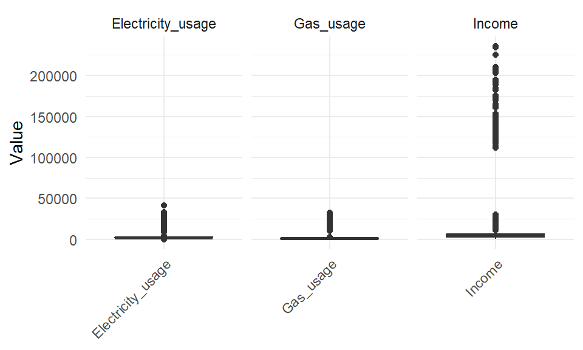

```r
# Convert data from wide to long format using pivot_longer
long_data <- data %>%
  pivot_longer(cols = c(Electricity_usage, Gas_usage, Income), names_to = "Variable", values_to = "Value")

# Plot with ggplot2
ggplot(long_data, aes(x = Variable, y = Value)) +
  geom_boxplot() +
  facet_wrap(~ Variable, scales = "free_x", nrow = 1) +
  labs(x = NULL, y = "Value") +
  theme_minimal() +
  theme(axis.text.x = element_text(angle = 45, hjust = 1))
```

Outliers in variables, “Income,” “Electricity_usage,” and “Gas_usage” were identified through the use of boxplots. This method highlights data points that lie outside the expected range. Further statistical analysis of summary statistics, has indicated significant deviations in these variables, especially in terms of their mean and standard deviations. This was evident in the case of “Income,” where values ranged at 235,350, with a mean of approximately 5,537 and a substantial standard deviation, indicating a widespread. Similarly, “Electricity_usage” showed a maximum value of 41,610, exceeding the mean usage of about 2,398, and “Gas_usage” peaked at 32,570, which was much higher than its mean of 1,332. These deviations highlight the presence of outliers that could potentially affect the overall analysis. Thus, it is considered that extremely high values in “Income”, Electricity_usage” and “Gas_usage,” may not accurately represent the general customer base, indicating anomalies, measurement errors, or data entry errors. Driven by the necessity to maintain data quality, ensuring that the analysis reflects the typical customer profile and is not skewed by extreme, atypical values, we proceed to the removal of these outliers. The methodology for the removal of these outliers is described below. By plotting the boxplots, it is observed that income, electricity, and gas usage have significant outliers and based on their values they were deleted. The number of observations is diminished to 19699. Below, it is explained analytically.

Income: All variables above value 30042 were deleted, as it was determined that this is the point where the values experience a significant breakpoint. This was done by calculating the point at which the greatest difference between the values of the variable is noticed. With only 60 variables (0.3%) having an income value above 30042, it was determined that deleting them wouldn’t skew the data negatively, due to the insignificant amount. Deletion was chosen over completion to minimize noise, simplify and strengthen the models, and avoid overfitting.  
Electricity Usage: All variables above 9000 in electricity usage were deleted. This was discovered through plot analysis and studying the units at the change points, with sorting employed for easier and clearer understanding. Given that only 117 variables (0.585%) had electricity usage above 9000, it was determined that their deletion wouldn’t negatively skew the data, due to the insignificant amount.  
Gas Usage: All variables above 3209 were deleted using the same method as with the income. With only 125 variables (0.625%) having electricity usage above 3209, it was determined that deleting them wouldn’t negatively skew the data, given the insignificant amount.  
Age: It was chosen to remove all values where the age is less than 18, as it logically doesn’t make sense for someone who is not an adult to have a contract with the company